# Electric Vehicle Trends and Insights: A Data-Driven Analysis

## Introduction

Electric vehicles (EVs) are transforming the transportation industry, driven by the need for cleaner energy and sustainable solutions. This project analyzes trends in electric vehicles using real-world data, uncovering insights into adoption patterns, manufacturer dominance, and performance characteristics.

## Objectives

- Explore the distribution of EV types (Battery Electric Vehicles and Plug-in Hybrid Electric Vehicles).
- Analyze EV adoption patterns by geographical location.
- Understand EV adoption trends over time and across manufacturers.
- Assess EV performance trends, such as electric range.

## Dataset Overview

The dataset contains detailed information about electric vehicles, including:

- Registration locations (county, city, and state).
- Vehicle specifications (make, model, year, and electric range).
- EV type: Battery Electric Vehicle (BEV) or Plug-in Hybrid Electric Vehicle (PHEV).

## Data Cleaning

Before conducting analysis, it's important to clean the data. This includes:

- Checking for missing values.
- Handling inconsistent data entries.
- Dropping irrelevant columns if necessary.

```python
# Import required libraries
import pandas as pd
import matplotlib.pyplot as plt

# Load the dataset
file_path = 'Electric_Vehicle_Population_Data.csv'
df = pd.read_csv(file_path)

# Check for missing values
missing_values = df.isnull().sum()
print("Missing values in each column:")
print(missing_values)

# Drop rows with missing data in critical columns
df = df.dropna(subset=['Electric Vehicle Type', 'Model Year', 'Make'])

# Fill missing values in non-critical columns if necessary (e.g., location data)
df['County'] = df['County'].fillna('Unknown')

# Ensure all Model Year values are integers
df['Model Year'] = df['Model Year'].astype(int)

# Verify the cleaned data
print("\nData after cleaning:")
print(df.info())
```

```
Missing values in each column:
VIN (1-10)                                             0
County                                                 5
City                                                   5
State                                                  0
Postal Code                                            5
Model Year                                             0
Make                                                   0
Model                                                  0
Electric Vehicle Type                                  0
Clean Alternative Fuel Vehicle (CAFV) Eligibility      0
Electric Range                                        19
Base MSRP                                             19
Legislative District                                 451
DOL Vehicle ID                                         0
Vehicle Location                                      11
Electric Utility                                       5
2020 Census Tract                                      5
dtype: int64

Data after cleaning:
<class 'pandas.core.frame.DataFrame'>
RangeIndex: 216772 entries, 0 to 216771
Data columns (total 17 columns):
 #   Column                                             Non-Null Count   Dtype
---  ------                                             --------------   -----
 0   VIN (1-10)                                         216772 non-null  object
 1   County                                             216772 non-null  object
 2   City                                               216767 non-null  object
 3   State                                              216772 non-null  object
 4   Postal Code                                        216767 non-null  float64
 5   Model Year                                         216772 non-null  int64
 6   Make                                               216772 non-null  object
 7   Model                                              216772 non-null  object
 8   Electric Vehicle Type                              216772 non-null  object
 9   Clean Alternative Fuel Vehicle (CAFV) Eligibility  216772 non-null  object
 10  Electric Range                                     216753 non-null  float64
 11  Base MSRP                                          216753 non-null  float64
 12  Legislative District                               216321 non-null  float64
 13  DOL Vehicle ID                                     216772 non-null  int64
 14  Vehicle Location                                   216761 non-null  object
 15  Electric Utility                                   216767 non-null  object
 16  2020 Census Tract                                  216767 non-null  float64
dtypes: float64(5), int64(2), object(10)
memory usage: 28.1+ MB
None
```

## Exploratory Data Analysis (EDA)

### 1. Trends in Electric Vehicle Types

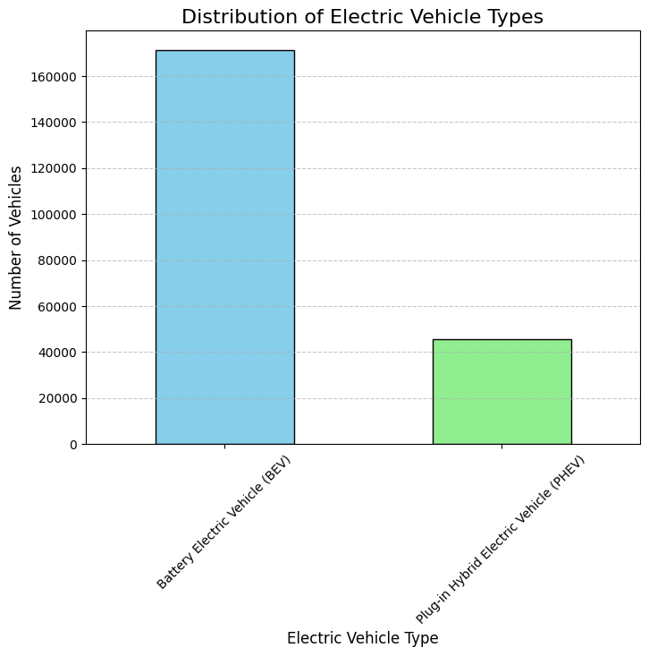

```python
# Import required libraries
import pandas as pd
import matplotlib.pyplot as plt
# Analyze trends in EV types
ev_type_counts = df['Electric Vehicle Type'].value_counts()

# Plot the distribution of electric vehicle types
plt.figure(figsize=(8, 6))
ev_type_counts.plot(kind='bar', color=['skyblue', 'lightgreen'], edgecolor='black')
plt.title('Distribution of Electric Vehicle Types', fontsize=16)
plt.xlabel('Electric Vehicle Type', fontsize=12)
plt.ylabel('Number of Vehicles', fontsize=12)
plt.xticks(rotation=45, fontsize=10)
plt.grid(axis='y', linestyle='--', alpha=0.7)
plt.show()
```

### 2. Trends Over Time

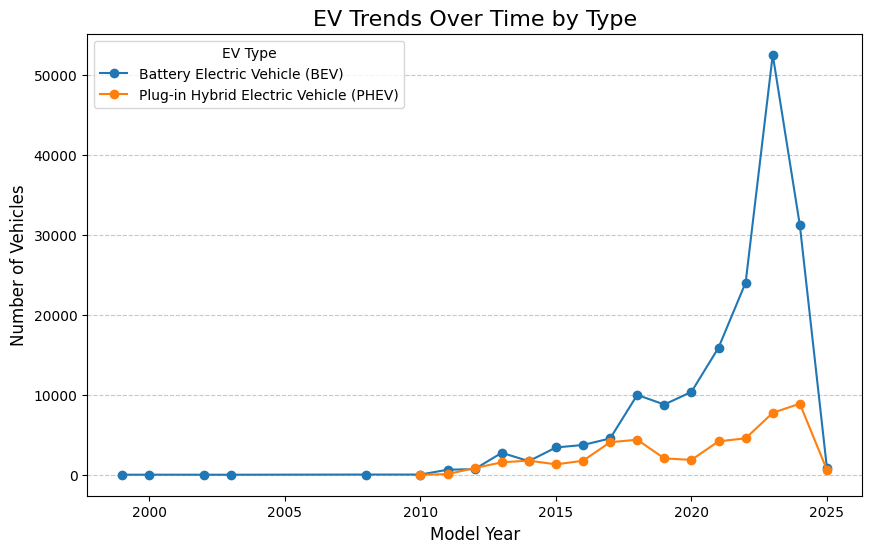

```python
# Import required libraries
import pandas as pd
import matplotlib.pyplot as plt
# Group data by model year and count the number of vehicles
yearly_trends = df.groupby('Model Year')['Electric Vehicle Type'].value_counts().unstack()

# Plot the trends over time
plt.figure(figsize=(10, 6))
yearly_trends.plot(kind='line', marker='o', ax=plt.gca())
plt.title('EV Trends Over Time by Type', fontsize=16)
plt.xlabel('Model Year', fontsize=12)
plt.ylabel('Number of Vehicles', fontsize=12)
plt.legend(title='EV Type', fontsize=10)
plt.grid(axis='y', linestyle='--', alpha=0.7)
plt.show()
```

### 3. Geographical Analysis

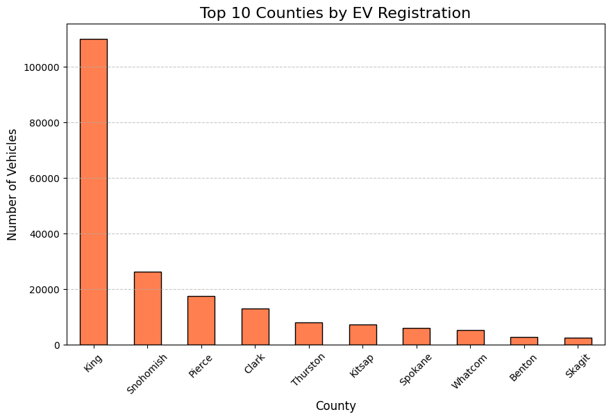

```python
# Import required libraries
import pandas as pd
import matplotlib.pyplot as plt
# Count vehicles by county
county_counts = df['County'].value_counts().head(10)  # Top 10 counties

# Plot vehicle distribution by county
plt.figure(figsize=(10, 6))
county_counts.plot(kind='bar', color='coral', edgecolor='black')
plt.title('Top 10 Counties by EV Registration', fontsize=16)
plt.xlabel('County', fontsize=12)
plt.ylabel('Number of Vehicles', fontsize=12)
plt.xticks(rotation=45, fontsize=10)
plt.grid(axis='y', linestyle='--', alpha=0.7)
plt.show()
```

### 4. Manufacturer Dominance

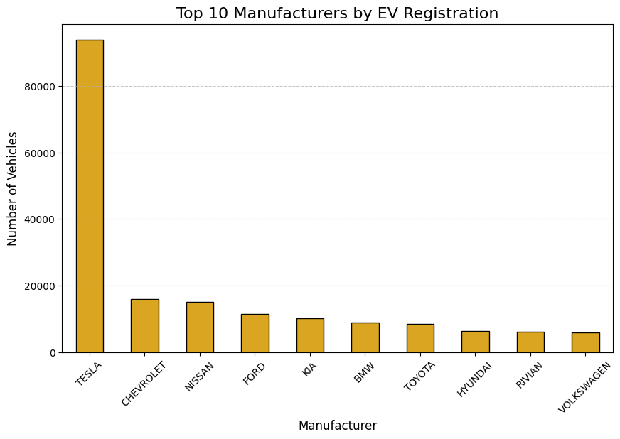

```python
# Import required libraries
import pandas as pd
import matplotlib.pyplot as plt
# Count vehicles by manufacturer
manufacturer_counts = df['Make'].value_counts().head(10)  # Top 10 manufacturers

# Plot manufacturer dominance
plt.figure(figsize=(10, 6))
manufacturer_counts.plot(kind='bar', color='goldenrod', edgecolor='black')
plt.title('Top 10 Manufacturers by EV Registration', fontsize=16)
plt.xlabel('Manufacturer', fontsize=12)
plt.ylabel('Number of Vehicles', fontsize=12)
plt.xticks(rotation=45, fontsize=10)
plt.grid(axis='y', linestyle='--', alpha=0.7)
plt.show()
```